# Snowshoe Hares Exploratory Report - Bonanza Creek Experimental Project

# 4. Juvenile Snowshoe Hare Data Exploration

## 4.1 Visualization of Juvenile Hare Weights

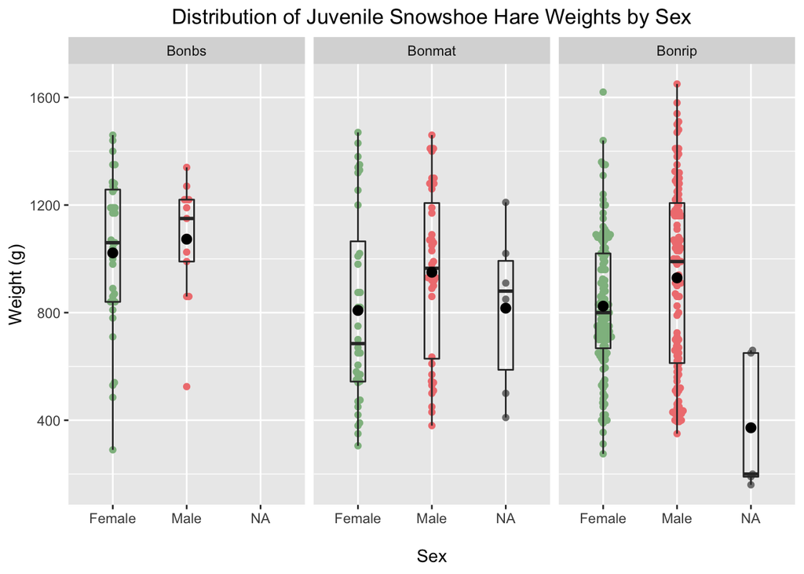

**Figure 2.** Weight distribution of juvenile hares separated by sex at three sample sites. Sex is on the x-axis, weight is on the y-axis, and the data is faceted by site. Data: (Kielland et al. 2017).

**Findings:** The graph above shows how there are slight differences in weight based on sex and site of snowshoe hares. Maximum weights for male and female hares were observed at Bonrip, but there is not a notable difference in weight distribution across the three sites. Male hare weights appear slightly larger than female on average. Bonbs, the lowland black spruce site, has the least counts, which might influence its summary statistics as represented by the box plot.

## 4.2 Statistics of Juvenile Hare Weights

**Table 2.** Summary statistics for male and female juvenile hares. Data: (Kielland et al. 2017).

| Sex | Mean Weight (g) | Median Weight (g) | Standard Deviation (g) | Max Weight (g) | Minimum Weight (g) | Sample Size |
| --- | --- | --- | --- | --- | --- | --- |
| Female | 855.39 | 825 | 292.25 | 1620 | 275 | 197 |
| Male | 945.86 | 990 | 333.22 | 1650 | 350 | 163 |

**Findings:** Exploratory graphs were used to test assumptions of normalcy and homoscedasticity, which appeared to be fully normal for further statistical analysis to be valuable. The mean weight of male juvenile hares is 945.9 g and that of female juvenile hares is 855.4 g, which has a difference of 90.5 g. Considering the standard deviation in male hares weight is 333.2 g and 292.3 g for females, this difference appears negligible. This is corroborated by the small effect size (Cohen’s *d* = 0.29), but the two-sample t-test suggests there is a significant difference in the sample means (two-sample t-test, t = 2.71, p = 0.007).

## 4.3 Juvenile Weight & Hind Foot Length

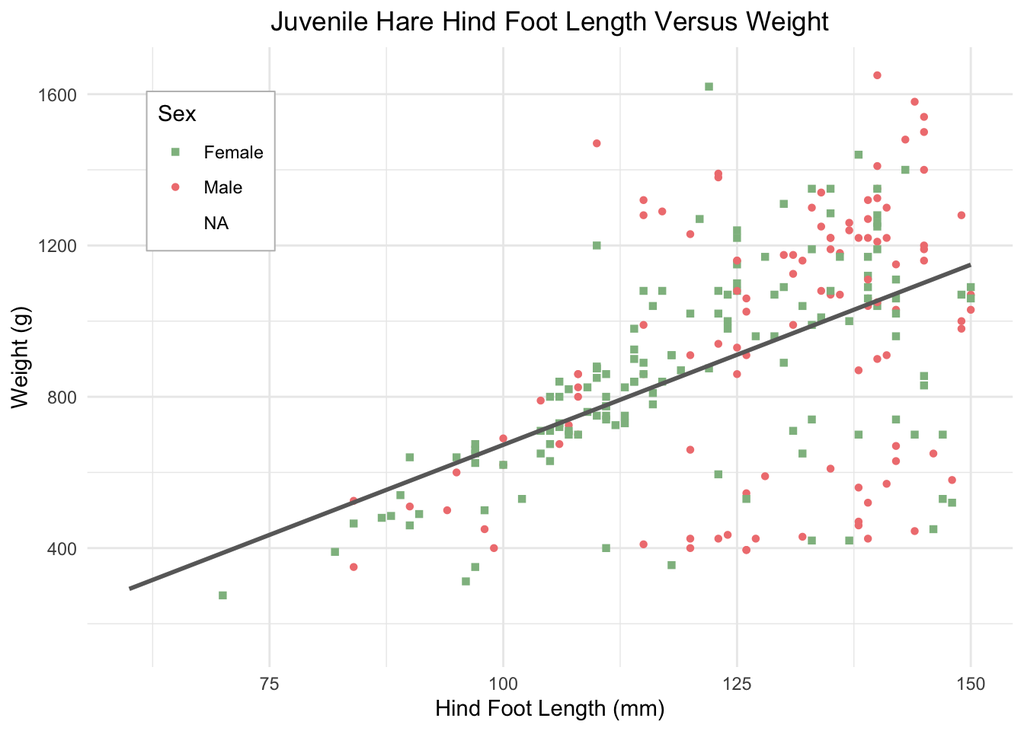

**Figure 3.** Weight distribution (g) of juvenile hares compared to hind foot length (mm). Hind foot length is on the x-axis and weight is on the y-axis. For trend clarity, female hares are represented by green squares and male are red circles. Data: (Kielland et al. 2017).

**Findings:** This graph shows the linear relationship between juvenile hare weight and hindfoot length, which shows a significant linear relationship although it is not very strong. Simple linear regression showed that hindfoot length does not do the best job at predicting snowshoe hare weight (p < 0.001, R^2 = 0.3) with an average slope of $\beta$ = 9.5 g mm<sup>-1</sup>. This means that with one millimeter increase in hindfoot length, we expect an average increase in hare weight of 9.5 g. Hindfoot length and hare weight are positively correlated, according to this linear regression (Pearson’s *r* = 0.55, p < 0.001). In this case, the linear regression ignores if homoscedasticity is normal. The variance of standard error seems not homogeneous throughout the sample shown by diagnostic plots (not shown), especially for male snowshoe hares. I believe the data does not meet the conditions for a linear regression to accurately represent the relationship of hindfoot length with hare weight for both sexes at once.

# 5. Summary

This exploratory data analysis reveals the following:

- The number of juvenile hare trap counts declined overall from the beginning of sampling in 1999 to the end in 2012.
- Male and female juvenile snowshoe hares have a statistically significant difference in mean weights, although the effect size is small.
- Juvenile hare hind foot length and weight do not have a strong linear relationship, as defined by simple linear regression. The linear regressions shows suggests that we can expect on average that with every 1 mm increase in hind foot length that hare weight will increase by 9.5 g mm<sup>-1</sup>, but the low Pearson’s r value and R^2 suggest this trend is not a good representation of these characteristics in snowshoe hares.

# Citation:

Kielland, K., F.S. Chapin, R.W. Ruess, and Bonanza Creek LTER. 2017. Snowshoe hare physical data in Bonanza Creek Experimental Forest: 1999-Present ver 22. Environmental Data Initiative. https://doi.org/10.6073/pasta/03dce4856d79b91557d8e6ce2cbcdc14